# TECHNICAL REPORT - ANALYSING FAKE NEWS

Author: Amir Yunus  
GitHub: https://github.com/AmirYunus/GA_DSI_Project_2

# PREFACE

## Problem Statement

Suppose that a government agency wants to tackle the rise of fake news and scam in the community. We have proposed to use scrape reddit posts to help build our model. The agency aims the following:

- At least a 95% accuracy for the training set
- At least a 95% accuracy for a separate testing set, unseen by the model
- Test reddit model on news and articles from external websites:
  - What is the accuracy?
  - What are areas of improvement?

## Executive Summary

For this project, we will consider the 2 classes: Fake News and Real News.

There are many definitions to what may constitute a fake news. For the purposes of our analysis, we will consider the following sub-reddits as fake news:

- `r/conspiracy` - A subreddit with posts on conspiracy theories
- `r/Alternativefacts` - A subreddit with posts of 'alternative facts' as coined by U.S. Counselor to the President Kellyanne Conway
- `r/scambaiting` - A subreddit with posts related to scams and scambaiting
- `r/satire` - A subreddit with posts of parody and satire of current events

As we have taken fake news from four sources, we will also consider 4 factual sources to balance our training data.

- `r/worldnews` - A subreddit with news around the world, no later than 1 week old
- `r/politics` - A subreddit with politcal news, but tend towards American politics
- `r/business` - A subreddit with financial, economy and business trends
- `r/technology` - A subreddit with gaming, data and tecnological advancements

As reddit is limiting scrapes to only 1,000 posts per time, we will be continuously scraping and append new results to the old DataFrame.

After scraping, we will look at the most common words for each category - fake and real news. After which, we will run a few models to consider if raw, pre-processed or lemmatization will yield the highest accuracy. Once we can determine the type of data, we will run a grid search on the parameters that will give the best results.

The final model is then fitted with a user-input content. User may input a real or fake news, title or body content of their liking, and run against the model.

# Table of Contents

## Data Dictionary

| Feature | Type | Dataset | Description |
| --- | --- | --- | --- |
| df_fake.content | string | r/conspiracy r/Alternativefacts r/scambaiting r/satire | Fake news scraped from reddit |
| df_news.content | string | r/worldnews r/politics r/business r/technology | Real news scraped from reddit |
| df_onion.content | string | r/nottheonion | Real news that appears fake scraped from reddit |
| is_fake | int | (All above) | 1: source is fake 0: source is real |
| pred_fake | int | model | 1: source is predicted to be fake 0: source is predicted to be real |

## Libraries

In this notebook, we will try to keep it clean. Therefore, all functions are compiled into a single class. The Python code `functions.py` is part of this technical report. We will import the class, `project_3`, and rename it as `p3` for brevity.

```python
# Allows Jupyter to reload custom module without restarting kernel
%load_ext autoreload
%autoreload 2
```

```
The autoreload extension is already loaded. To reload it, use:
  %reload_ext autoreload
```

```python
# Import custom class project_3 as p3 from functions.py
from functions import project_3 as p3
```

# DATA GATHERING

## Scraping Reddit for Fake News

We will scrape the following four subreddits for fake news:

- `r/conspiracy`
- `r/Alternativefacts`
- `r/scambaiting`
- `r/satire`

The code to scrape is turned off (i.e set to `False`), so that we do not accidentally run them unless we want to.

When scraping, we will get posts for `hot`, `new`, `all-time controversial`, `all-time top`, and `rising` for each topic. After scraping we will assign a new feature called `is_fake` and set it to 1.

```python
# Scraping set to False. To scrape, set to True
p3.fake('conspiracy','Alternativefacts','scambaiting','satire',False)
```

In the event that we have already scraped the data, we will load them into this report as `df_fake`.

```python
# Loading fake.csv as df_fake
df_fake = p3.read('fake')
```

**CHECK:** There are 51420 posts with 115 columns

## Scraping Reddit for Real News

We will scrape the following four subreddits for real news:

- `r/worldnews`
- `r/politics`
- `r/business`
- `r/technology`

The code to scrape is turned off (i.e set to `False`), so that we do not accidentally run them unless we want to.

When scraping, we will get posts for `hot`, `new`, `all-time controversial`, `all-time top`, and `rising` for each topic. After scraping we will assign a new feature called `is_fake` and set it to 0.

```python
# Scraping set to False. To scrape, set to True
p3.news('worldnews','politics','business','technology',False)
```

In the event that we have already scraped the data, we will load them into this report as `df_news`.

```python
# Loading news.csv as df_news
df_news = p3.read('news')
```

**CHECK:** There are 65349 posts with 118 columns

# EXPLORATORY DATA ANALYSIS

## Data Source

Our data is from reddit, one of the most active social media platform as of writing. As with all social media outlets, it is prone to false information and fake news. It is heavily reliant on users posting new information onto their platform, and to earn points, some may even post a controversial comment or article.

Nevertheless, reddit has a few channels that are controlled and data sources from these channels are reliable. These sources, such as `r/worldnews` and `r/business` were selected for their credibility and scraped as real news.

On the other hand, subreddits which are moderated by users themselves, tend to be less reliable. Especially so if they are posting topics such as `r/conspiracy` and `r/Alternativefacts`. These subreddits were scraped and labelled as fake news.

## Data Size

Before we perform any form of modelling, we need to ensure that we have a good sample size for our training model. Let us consider the size of our `df_fake`.

```python
# Check the size of df_fake
p3.check(f'Size of df_fake is {df_fake.shape[0]}')
```

**CHECK:** Size of df_fake is 51420

We have at least 50,000 posts of fake news, as at time of writing. Now consider `df_news`.

```python
# Check the size of df_news
p3.check(f'Size of df_news is {df_news.shape[0]}')
```

**CHECK:** Size of df_news is 65349

Real news have more unique posts of at least 65,000 as of writing. We would not want our training mdoel to be unbalanced. Let us consider only the top 50,000 rows from each class.

```python
df_fake = df_fake[:50000]
df_fake.shape
```

```
(50000, 115)
```

```python
df_news = df_news[:50000]
df_news.shape
```

```
(50000, 118)
```

We merge both datasets together as `df`.

```python
# Merge the DataFrames and check the size
df = p3.merge(df_news,df_fake).reset_index().drop('index',axis=1)
y = df.is_fake
df.drop('is_fake', inplace=True, axis=1)
```

**CHECK:** There are 100000 posts with 2 columns

```python
# Check the classification. 1 = fake news, 0 = real news
y.value_counts(normalize=True)
```

```
1    0.5
0    0.5
Name: is_fake, dtype: float64
```

The distribution of 0.5 is expected as we have selected the exact number of observations per class.

# DATA VISUALISATION

## Top Common Words for Fake News

What were the common words to appear in fake news articles?

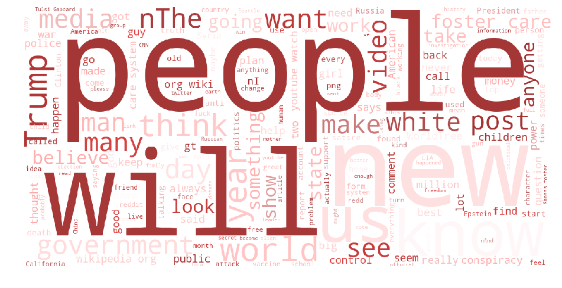

```python
# Display wordcloud for df_fake
p3.wordcloud(df_fake.content,'fake')
```

```python
# Display top 10 words for df_fake
words = p3.features(df_fake,df_fake.is_fake)
```

```
28847
```

**NOTE:** Top 10 words

| is_fake | 1 |
| --- | --- |
| trump | 8511 |
| people | 5999 |
| will | 5528 |
| us | 3766 |
| know | 3604 |
| new | 3407 |
| reddit | 3033 |
| news | 2958 |
| conspiracy | 2718 |
| scammer | 2669 |

There are a few interesting keywords from the wordcloud above, such as:

- Trump; and
- conspiracy

Let us consider the common words for real news.

## Top Common Words for Real News

[figure not shown]

```python
# Display wordcloud for df_news
p3.wordcloud(df_news.content,'news')
```

```python
# Display top 10 words for df_news
words = p3.features(df_news,df_news.is_fake)
```

```
27496
```

**NOTE:** Top 10 words

| is_fake | 0 |
| --- | --- |
| trump | 26527 |
| news | 7398 |
| politics | 5609 |
| us | 5573 |
| mueller | 4787 |
| russia | 4665 |
| cohen | 4630 |
| html | 4602 |
| says | 4072 |
| michael | 3961 |

There are a few interesting keywords from `df_news`, such as:

- Trump
- mueller
- russia; and
- cohen

Surprisingly, `Trump` appears as the most common word for both real and fake news and our model may have difficulty classifying it. Note, we have not processed this data for stopwords.

Let us consider the total size of our word features.

## Top Common Words for Training Data

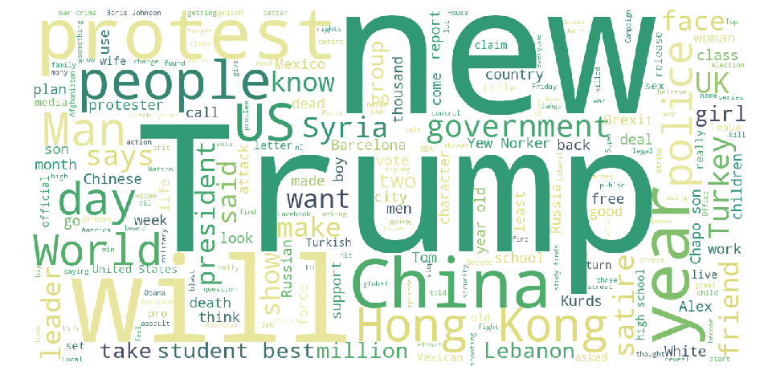

```python
# Display wordcloud for df
p3.wordcloud(df.content,'default')
```

```python
# Display top 10 words for training data
words = p3.features(df,y)
```

```
42901
```

**NOTE:** Top 10 words

| is_fake | 0 | 1 |
| --- | --- | --- |
| trump | 26527 | 8169 |
| news | 7398 | 2900 |
| will | 3902 | 5589 |
| us | 5573 | 3762 |
| people | 1855 | 5918 |
| new | 3413 | 3312 |
| politics | 5609 | 1030 |
| russia | 4665 | 1086 |
| html | 4602 | 844 |
| mueller | 4787 | 582 |

We have at least 42,000 words, as of writing, and after combining the unique words for both `df_fake` and `df_news`, we can see that `trump` is still leading as the first in both real and fake news.

# DATA ANALYSIS

Let us find which data source will provide us with the best `F1 Score`. We will use `GridSearchCV` to find the best `F1 Score`. The following vectorizers will be considered:

- `cv`: `CountVectorizer()`
- `tv`: `TfidfVectorizer()`
- `lr`: `LogisticRegression()`

And the following classifiers:

- `bnb`: `BernoulliNB()`
- `mnb`: `MultinomialNB()`
- `gnb`: `GaussianNB()`
- `knn`: `kNeighborsClassifer()`

Other parameters:

- `use_params`: Set whether to use grid search to find the best parameters

## Baseline Score

Before we start modelling, we need to determine the baseline score. In our situation, since we selected the same number of observations from both classes, our baseline score is 0.5.

```python
# Check the classification. 1 = fake news, 0 = real news
y.value_counts(normalize=True)
```

```
1    0.5
0    0.5
Name: is_fake, dtype: float64
```

## $M_0$ - Raw Data

This model utilises the best `F1 Score` using raw, unprocessed data.

```python
# Enter what vectorizers and classifiers we want to use and find the best.

vectorizer = ['cv','tv']
classifier = ['lr','bnb','mnb','knn']
use_params = False

df_solns, X_train, X_test, y_train, train_score, test_score, y_test, y_test_hat, best_params, f1_score = p3.search(vectorizer,classifier,df,y,use_params)
```

**Using CountVectorizer with LogisticRegression**

```
Fitting 2 folds for each of 1 candidates, totalling 2 fits
```

```
[Parallel(n_jobs=1)]: Using backend SequentialBackend with 1 concurrent workers.
[Parallel(n_jobs=1)]: Done   2 out of   2 | elapsed:   20.2s finished
```

```
Train score: 0.8885733333333333
Test score: 0.87896 (Accuracy)

True Negatives: 10876
False Positives: 1624 (Type I Error)
False Negatives: 1402 (Type II Error)
True Positives: 11098
```

**Sensitivity:** 0.88784

**Miss Rate:** 0.11216

**Specificity:** 0.87008

**Fall Out Rate:** 0.12992

**Precision:** 0.8723471152334539

**False Discovery Rate:** 0.12765288476654615

**Negative Predictive Value:** 0.8858120215018732

**False Omission Rate:** 0.11418797849812673

**Prevalence:** 0.5

**Accuracy:** 0.87896

**Positive Likelihood Ratio:** 6.833743842364531

**Negative Likelihood Ratio:** 0.1289076866495035

**Diagnostic Odds Ratio:** 53.01269474290773

**F1 Score:** 0.8800253746729045

**CHECK:** Completed CountVectorizer with LogisticRegression

**Using CountVectorizer with BernoulliNB**

```
Fitting 2 folds for each of 1 candidates, totalling 2 fits
```

```
[Parallel(n_jobs=1)]: Using backend SequentialBackend with 1 concurrent workers.
[Parallel(n_jobs=1)]: Done   2 out of   2 | elapsed:    7.2s finished
```

```
Train score: 0.6682
Test score: 0.687 (Accuracy)

True Negatives: 11929
False Positives: 571 (Type I Error)
False Negatives: 7254 (Type II Error)
True Positives: 5246
```

**Sensitivity:** 0.41968

**Miss Rate:** 0.58032

**Specificity:** 0.95432

**Fall Out Rate:** 0.04568

**Precision:** 0.901839436135465

**False Discovery Rate:** 0.09816056386453498

**Negative Predictive Value:** 0.6218526820622426

**False Omission Rate:** 0.3781473179377574

**Prevalence:** 0.5

**Accuracy:** 0.687

**Positive Likelihood Ratio:** 9.187390542907181

**Negative Likelihood Ratio:** 0.6080979126498449

**Diagnostic Odds Ratio:** 15.108406642726738

**F1 Score:** 0.5728012229076814

**CHECK:** Completed CountVectorizer with BernoulliNB

**Using CountVectorizer with MultinomialNB**

```
Fitting 2 folds for each of 1 candidates, totalling 2 fits
```

```
[Parallel(n_jobs=1)]: Using backend SequentialBackend with 1 concurrent workers.
[Parallel(n_jobs=1)]: Done   2 out of   2 | elapsed:    6.9s finished
```

```
Train score: 0.7966133333333333
Test score: 0.81688 (Accuracy)

True Negatives: 9634
False Positives: 2866 (Type I Error)
False Negatives: 1712 (Type II Error)
True Positives: 10788
```

**Sensitivity:** 0.86304

**Miss Rate:** 0.13696

**Specificity:** 0.77072

**Fall Out Rate:** 0.22928

**Precision:** 0.7900981397392706

**False Discovery Rate:** 0.20990186026072946

**Negative Predictive Value:** 0.8491098184382161

**False Omission Rate:** 0.15089018156178388

**Prevalence:** 0.5

**Accuracy:** 0.81688

**Positive Likelihood Ratio:** 3.7641311933007677

**Negative Likelihood Ratio:** 0.17770396512352088

**Diagnostic Odds Ratio:** 21.182032661366584

**F1 Score:** 0.8249598531773343

**CHECK:** Completed CountVectorizer with MultinomialNB

**Using CountVectorizer with KNeighborsClassifier**

```
Fitting 2 folds for each of 1 candidates, totalling 2 fits
```

```
[Parallel(n_jobs=1)]: Using backend SequentialBackend with 1 concurrent workers.
[Parallel(n_jobs=1)]: Done   2 out of   2 | elapsed:  1.9min finished
```

```
Train score: 0.64152
Test score: 0.81608 (Accuracy)

True Negatives: 8049
False Positives: 4451 (Type I Error)
False Negatives: 147 (Type II Error)
True Positives: 12353
```

**Sensitivity:** 0.98824

**Miss Rate:** 0.01176

**Specificity:** 0.64392

**Fall Out Rate:** 0.35608

**Precision:** 0.7351225898595573

**False Discovery Rate:** 0.26487741014044275

**Negative Predictive Value:** 0.9820644216691069

**False Omission Rate:** 0.01793557833089312

**Prevalence:** 0.5

**Accuracy:** 0.81608

**Positive Likelihood Ratio:** 2.7753313862053473

**Negative Likelihood Ratio:** 0.018263138278046962

**Diagnostic Odds Ratio:** 151.963553248754

**F1 Score:** 0.8430930930930931

**CHECK:** Completed CountVectorizer with KNeighborsClassifier

**Using TfidfVectorizer with LogisticRegression**

```
Fitting 2 folds for each of 1 candidates, totalling 2 fits
```

```
[Parallel(n_jobs=1)]: Using backend SequentialBackend with 1 concurrent workers.
[Parallel(n_jobs=1)]: Done   2 out of   2 | elapsed:    8.1s finished
```

```
Train score: 0.8811733333333334
Test score: 0.91208 (Accuracy)

True Negatives: 11359
False Positives: 1141 (Type I Error)
False Negatives: 1057 (Type II Error)
True Positives: 11443
```

**Sensitivity:** 0.91544

**Miss Rate:** 0.08456

**Specificity:** 0.90872

**Fall Out Rate:** 0.09128

**Precision:** 0.9093293070565798

**False Discovery Rate:** 0.09067069294342021

**Negative Predictive Value:** 0.9148679123711341

**False Omission Rate:** 0.08513208762886598

**Prevalence:** 0.5

**Accuracy:** 0.91208

**Positive Likelihood Ratio:** 10.028921998247151

**Negative Likelihood Ratio:** 0.0930539660181354

**Diagnostic Odds Ratio:** 107.77533110509876

**F1 Score:** 0.9123744219422739

**CHECK:** Completed TfidfVectorizer with LogisticRegression

**Using TfidfVectorizer with BernoulliNB**

```
Fitting 2 folds for each of 1 candidates, totalling 2 fits
```

```
[Parallel(n_jobs=1)]: Using backend SequentialBackend with 1 concurrent workers.
[Parallel(n_jobs=1)]: Done   2 out of   2 | elapsed:    7.0s finished
```

```
Train score: 0.6682
Test score: 0.687 (Accuracy)

True Negatives: 11929
False Positives: 571 (Type I Error)
False Negatives: 7254 (Type II Error)
True Positives: 5246
```

**Sensitivity:** 0.41968

**Miss Rate:** 0.58032

**Specificity:** 0.95432

**Fall Out Rate:** 0.04568

**Precision:** 0.901839436135465

**False Discovery Rate:** 0.09816056386453498

**Negative Predictive Value:** 0.6218526820622426

**False Omission Rate:** 0.3781473179377574

**Prevalence:** 0.5

**Accuracy:** 0.687

**Positive Likelihood Ratio:** 9.187390542907181

**Negative Likelihood Ratio:** 0.6080979126498449

**Diagnostic Odds Ratio:** 15.108406642726738

**F1 Score:** 0.5728012229076814

**CHECK:** Completed TfidfVectorizer with BernoulliNB

**Using TfidfVectorizer with MultinomialNB**

```
Fitting 2 folds for each of 1 candidates, totalling 2 fits
```

```
[Parallel(n_jobs=1)]: Using backend SequentialBackend with 1 concurrent workers.
[Parallel(n_jobs=1)]: Done   2 out of   2 | elapsed:    7.0s finished
```

```
Train score: 0.8680133333333333
Test score: 0.89296 (Accuracy)

True Negatives: 11241
False Positives: 1259 (Type I Error)
False Negatives: 1417 (Type II Error)
True Positives: 11083
```

**Sensitivity:** 0.88664

**Miss Rate:** 0.11336

**Specificity:** 0.89928

**Fall Out Rate:** 0.10072

**Precision:** 0.8979906011991573

**False Discovery Rate:** 0.10200939880084266

**Negative Predictive Value:** 0.8880549849897298

**False Omission Rate:** 0.11194501501027018

**Prevalence:** 0.5

**Accuracy:** 0.89296

**Positive Likelihood Ratio:** 8.803018268467037

**Negative Likelihood Ratio:** 0.12605640067609644

**Diagnostic Odds Ratio:** 69.83396496530554

**F1 Score:** 0.8922792045729008

**CHECK:** Completed TfidfVectorizer with MultinomialNB

**Using TfidfVectorizer with KNeighborsClassifier**

```
Fitting 2 folds for each of 1 candidates, totalling 2 fits
```

```
[Parallel(n_jobs=1)]: Using backend SequentialBackend with 1 concurrent workers.
[Parallel(n_jobs=1)]: Done   2 out of   2 | elapsed:  1.8min finished
```

```
Train score: 0.5743333333333334
Test score: 0.76584 (Accuracy)

True Negatives: 6681
False Positives: 5819 (Type I Error)
False Negatives: 35 (Type II Error)
True Positives: 12465
```

**Sensitivity:** 0.9972

**Miss Rate:** 0.0028

**Specificity:** 0.53448

**Fall Out Rate:** 0.46552

**Precision:** 0.6817436009625902

**False Discovery Rate:** 0.31825639903740977

**Negative Predictive Value:** 0.9947885646217987

**False Omission Rate:** 0.00521143537820131

**Prevalence:** 0.5

**Accuracy:** 0.76584

**Positive Likelihood Ratio:** 2.1421206392851007

**Negative Likelihood Ratio:** 0.00523873671606047

**Diagnostic Odds Ratio:** 408.9002283161073

**F1 Score:** 0.8098362785862786

**CHECK:** Completed TfidfVectorizer with KNeighborsClassifier

**SUCCESS:** **COMPLETED**

Let us see what is the best model.

```python
# Display the best model
df_solns = df_solns.sort_values(ascending=False, by='f1_score',axis=1)
df_solns.iloc[:,0:1]
```

|  | 5 |
| --- | --- |
| best_params | {} |
| f1_score | 0.912374 |
| model | lr |
| test_score | 0.91208 |
| train_score | 0.881173 |
| vectorizer | tv |

For our benchmark ($M_0$) model, we will use `TfidfVectorizer` with `LogisticRegression` which yields an `F1 Score` of `0.912374`.

## $M_1$ - Processed Data

In this model, we will use `BeautifulSoup` and `RegEx` to clean our data. However, we will not use `Lemmatization` for this model. Stopwords are not removed as well.

```python
# Clean the training data and assign it to df_processed
df_processed = p3.clean(df,lemma=False)
```

Cleaned 10000 rows out of 100000

Cleaned 20000 rows out of 100000

Cleaned 30000 rows out of 100000

Cleaned 40000 rows out of 100000

Cleaned 50000 rows out of 100000

Cleaned 60000 rows out of 100000

Cleaned 70000 rows out of 100000

Cleaned 80000 rows out of 100000

Cleaned 90000 rows out of 100000

Cleaned 100000 rows out of 100000

**SUCCESS:** 100000 rows cleaned

Let us see if the number of words dropped after cleaning.

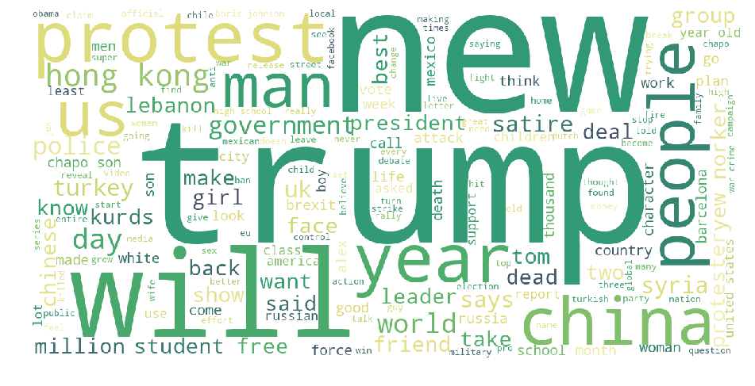

```python
# Display wordcloud for df
p3.wordcloud(df_processed,'default')
```

```python
# Display top 10 words for processed data
words_processed = p3.features(df_processed,y)
```

```
35559
```

**NOTE:** Top 10 words

| is_fake | 0 | 1 |
| --- | --- | --- |
| trump | 26645 | 8121 |
| news | 7500 | 2818 |
| us | 6012 | 3742 |
| will | 3900 | 5593 |
| people | 1857 | 5928 |
| new | 3424 | 3330 |
| politics | 5640 | 899 |
| russia | 4690 | 1080 |
| mueller | 4820 | 596 |
| html | 4612 | 764 |

We can see that the number of features dropped from `42901` to `35559`. The top common words did not change though, with `trump`, `russia` and `mueller` in the top 10.

Let us find out what is the best model for our $M_1$.

```python
# Enter what vectorizers and classifiers we want to use and find the best.

vectorizer = ['cv','tv']
classifier = ['lr','bnb','mnb','knn']
use_params = False

df_solns, X_train, X_test, y_train, train_score, test_score, y_test, y_test_hat, best_params, f1_score = p3.search(vectorizer,classifier,df,y,use_params)
```

**Using CountVectorizer with LogisticRegression**

```
Fitting 2 folds for each of 1 candidates, totalling 2 fits
```

```
[Parallel(n_jobs=1)]: Using backend SequentialBackend with 1 concurrent workers.
[Parallel(n_jobs=1)]: Done   2 out of   2 | elapsed:   14.3s finished
```

```
Train score: 0.88072
Test score: 0.88248 (Accuracy)

True Negatives: 11000
False Positives: 1500 (Type I Error)
False Negatives: 1438 (Type II Error)
True Positives: 11062
```

**Sensitivity:** 0.88496

**Miss Rate:** 0.11504

**Specificity:** 0.88

**Fall Out Rate:** 0.12

**Precision:** 0.8805922623786021

**False Discovery Rate:** 0.11940773762139786

**Negative Predictive Value:** 0.8843865573243287

**False Omission Rate:** 0.11561344267567134

**Prevalence:** 0.5

**Accuracy:** 0.88248

**Positive Likelihood Ratio:** 7.374666666666666

**Negative Likelihood Ratio:** 0.13072727272727272

**Diagnostic Odds Ratio:** 56.41261010662958

**F1 Score:** 0.8827707285930891

**CHECK:** Completed CountVectorizer with LogisticRegression

**Using CountVectorizer with BernoulliNB**

```
Fitting 2 folds for each of 1 candidates, totalling 2 fits
```

```
[Parallel(n_jobs=1)]: Using backend SequentialBackend with 1 concurrent workers.
[Parallel(n_jobs=1)]: Done   2 out of   2 | elapsed:    6.3s finished
```

```
Train score: 0.6681066666666666
Test score: 0.68708 (Accuracy)

True Negatives: 11908
False Positives: 592 (Type I Error)
False Negatives: 7231 (Type II Error)
True Positives: 5269
```

**Sensitivity:** 0.42152

**Miss Rate:** 0.57848

**Specificity:** 0.95264

**Fall Out Rate:** 0.04736

**Precision:** 0.8989933458454189

**False Discovery Rate:** 0.10100665415458113

**Negative Predictive Value:** 0.622185067140394

**False Omission Rate:** 0.37781493285960605

**Prevalence:** 0.5

**Accuracy:** 0.68708

**Positive Likelihood Ratio:** 8.900337837837839

**Negative Likelihood Ratio:** 0.6072388310379576

**Diagnostic Odds Ratio:** 14.657063058079517

**F1 Score:** 0.5739338815968629

**CHECK:** Completed CountVectorizer with BernoulliNB

**Using CountVectorizer with MultinomialNB**

```
Fitting 2 folds for each of 1 candidates, totalling 2 fits
```

```
[Parallel(n_jobs=1)]: Using backend SequentialBackend with 1 concurrent workers.
[Parallel(n_jobs=1)]: Done   2 out of   2 | elapsed:    6.2s finished
```

```
Train score: 0.7934266666666666
Test score: 0.81404 (Accuracy)

True Negatives: 9620
False Positives: 2880 (Type I Error)
False Negatives: 1769 (Type II Error)
True Positives: 10731
```

**Sensitivity:** 0.85848

**Miss Rate:** 0.14152

**Specificity:** 0.7696

**Fall Out Rate:** 0.2304

**Precision:** 0.7884064359709059

**False Discovery Rate:** 0.21159356402909413

**Negative Predictive Value:** 0.8446746861006235

**False Omission Rate:** 0.1553253138993766

**Prevalence:** 0.5

**Accuracy:** 0.81404

**Positive Likelihood Ratio:** 3.7260416666666667

**Negative Likelihood Ratio:** 0.1838877338877339

**Diagnostic Odds Ratio:** 20.26258950442811

**F1 Score:** 0.8219524338401439

**CHECK:** Completed CountVectorizer with MultinomialNB

**Using CountVectorizer with KNeighborsClassifier**

```
Fitting 2 folds for each of 1 candidates, totalling 2 fits
```

```
[Parallel(n_jobs=1)]: Using backend SequentialBackend with 1 concurrent workers.
[Parallel(n_jobs=1)]: Done   2 out of   2 | elapsed:  1.8min finished
```

```
Train score: 0.64816
Test score: 0.82008 (Accuracy)

True Negatives: 8155
False Positives: 4345 (Type I Error)
False Negatives: 153 (Type II Error)
True Positives: 12347
```

**Sensitivity:** 0.98776

**Miss Rate:** 0.01224

**Specificity:** 0.6524

**Fall Out Rate:** 0.3476

**Precision:** 0.7396956625928589

**False Discovery Rate:** 0.26030433740714115

**Negative Predictive Value:** 0.9815840154068368

**False Omission Rate:** 0.018415984593163216

**Prevalence:** 0.5

**Accuracy:** 0.82008

**Positive Likelihood Ratio:** 2.841657077100115

**Negative Likelihood Ratio:** 0.0187614960147149

**Diagnostic Odds Ratio:** 151.4621795016434

**F1 Score:** 0.8459166895039737

**CHECK:** Completed CountVectorizer with KNeighborsClassifier

**Using TfidfVectorizer with LogisticRegression**

```
Fitting 2 folds for each of 1 candidates, totalling 2 fits
```

```
[Parallel(n_jobs=1)]: Using backend SequentialBackend with 1 concurrent workers.
[Parallel(n_jobs=1)]: Done   2 out of   2 | elapsed:    7.5s finished
```

```
Train score: 0.8791466666666666
Test score: 0.90936 (Accuracy)

True Negatives: 11316
False Positives: 1184 (Type I Error)
False Negatives: 1082 (Type II Error)
True Positives: 11418
```

**Sensitivity:** 0.91344

**Miss Rate:** 0.08656

**Specificity:** 0.90528

**Fall Out Rate:** 0.09472

**Precision:** 0.9060466592604348

**False Discovery Rate:** 0.09395334073956514

**Negative Predictive Value:** 0.9127278593321504

**False Omission Rate:** 0.08727214066784965

**Prevalence:** 0.5

**Accuracy:** 0.90936

**Positive Likelihood Ratio:** 9.64358108108108

**Negative Likelihood Ratio:** 0.09561682573347473

**Diagnostic Odds Ratio:** 100.85652820102912

**F1 Score:** 0.9097283085013146

**CHECK:** Completed TfidfVectorizer with LogisticRegression

**Using TfidfVectorizer with BernoulliNB**

```
Fitting 2 folds for each of 1 candidates, totalling 2 fits
```

```
[Parallel(n_jobs=1)]: Using backend SequentialBackend with 1 concurrent workers.
[Parallel(n_jobs=1)]: Done   2 out of   2 | elapsed:    6.4s finished
```

```
Train score: 0.6681066666666666
Test score: 0.68708 (Accuracy)

True Negatives: 11908
False Positives: 592 (Type I Error)
False Negatives: 7231 (Type II Error)
True Positives: 5269
```

**Sensitivity:** 0.42152

**Miss Rate:** 0.57848

**Specificity:** 0.95264

**Fall Out Rate:** 0.04736

**Precision:** 0.8989933458454189

**False Discovery Rate:** 0.10100665415458113

**Negative Predictive Value:** 0.622185067140394

**False Omission Rate:** 0.37781493285960605

**Prevalence:** 0.5

**Accuracy:** 0.68708

**Positive Likelihood Ratio:** 8.900337837837839

**Negative Likelihood Ratio:** 0.6072388310379576

**Diagnostic Odds Ratio:** 14.657063058079517

**F1 Score:** 0.5739338815968629

**CHECK:** Completed TfidfVectorizer with BernoulliNB

**Using TfidfVectorizer with MultinomialNB**

```
Fitting 2 folds for each of 1 candidates, totalling 2 fits
```

```
[Parallel(n_jobs=1)]: Using backend SequentialBackend with 1 concurrent workers.
[Parallel(n_jobs=1)]: Done   2 out of   2 | elapsed:    6.5s finished
```

```
Train score: 0.8667066666666666
Test score: 0.89244 (Accuracy)

True Negatives: 11230
False Positives: 1270 (Type I Error)
False Negatives: 1419 (Type II Error)
True Positives: 11081
```

**Sensitivity:** 0.88648

**Miss Rate:** 0.11352

**Specificity:** 0.8984

**Fall Out Rate:** 0.1016

**Precision:** 0.8971743178689985

**False Discovery Rate:** 0.10282568213100154

**Negative Predictive Value:** 0.8878172187524705

**False Omission Rate:** 0.11218278124752945

**Prevalence:** 0.5

**Accuracy:** 0.89244

**Positive Likelihood Ratio:** 8.7251968503937

**Negative Likelihood Ratio:** 0.1263579697239537

**Diagnostic Odds Ratio:** 69.0514169344054

**F1 Score:** 0.8917950987887812

**CHECK:** Completed TfidfVectorizer with MultinomialNB

**Using TfidfVectorizer with KNeighborsClassifier**

```
Fitting 2 folds for each of 1 candidates, totalling 2 fits
```

```
[Parallel(n_jobs=1)]: Using backend SequentialBackend with 1 concurrent workers.
[Parallel(n_jobs=1)]: Done   2 out of   2 | elapsed:  1.7min finished
```

```
Train score: 0.5764533333333334
Test score: 0.76768 (Accuracy)

True Negatives: 6721
False Positives: 5779 (Type I Error)
False Negatives: 29 (Type II Error)
True Positives: 12471
```

**Sensitivity:** 0.99768

**Miss Rate:** 0.00232

**Specificity:** 0.53768

**Fall Out Rate:** 0.46232

**Precision:** 0.6833424657534246

**False Discovery Rate:** 0.31665753424657533

**Negative Predictive Value:** 0.9957037037037038

**False Omission Rate:** 0.004296296296296296

**Prevalence:** 0.5

**Accuracy:** 0.76768

**Positive Likelihood Ratio:** 2.1579858106938916

**Negative Likelihood Ratio:** 0.004314834102068144

**Diagnostic Odds Ratio:** 500.13181495426375

**F1 Score:** 0.811121951219512

**CHECK:** Completed TfidfVectorizer with KNeighborsClassifier

**SUCCESS:** **COMPLETED**

```python
# Display the best model
df_solns = df_solns.sort_values(ascending=False, by='f1_score',axis=1)
df_solns.iloc[:,0:1]
```

|  | 5 |
| --- | --- |
| best_params | {} |
| f1_score | 0.909728 |
| model | lr |
| test_score | 0.90936 |
| train_score | 0.879147 |
| vectorizer | tv |

For our $M_1$, the best model is `TfidfVectorizer` with `LogisticRegression` with an `F1 Score` of `0.909728` which is lower than our benchmark score of `0.912374`.

## $M_2$ - Data with Lemmatization

In this model, we will use `BeautifulSoup` and `RegEx` to clean our data. `Lemmatization` will be used for to pick out common words. Stopwords are not removed for this model.

```python
# Cleaning our data with lemmatization
df_lemma = p3.clean(df,lemma=True)
```

Cleaned 10000 rows out of 100000

Cleaned 20000 rows out of 100000

Cleaned 30000 rows out of 100000

Cleaned 40000 rows out of 100000

Cleaned 50000 rows out of 100000

Cleaned 60000 rows out of 100000

Cleaned 70000 rows out of 100000

Cleaned 80000 rows out of 100000

Cleaned 90000 rows out of 100000

Cleaned 100000 rows out of 100000

**SUCCESS:** 100000 rows cleaned

Let us see the number of words after cleaning.

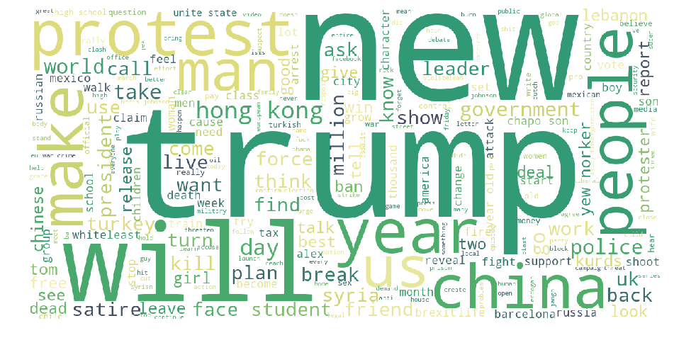

```python
# Display wordcloud for df
p3.wordcloud(df_lemma,'default')
```

```python
# Display top 10 words for processed data with lemmatization
words_lemma = p3.features(df_lemma,y)
```

```
29626
```

**NOTE:** Top 10 words

| is_fake | 0 | 1 |
| --- | --- | --- |
| trump | 27718 | 8262 |
| news | 7500 | 2818 |
| will | 4008 | 5769 |
| us | 6012 | 3742 |
| people | 1884 | 6032 |
| go | 2581 | 4773 |
| make | 2606 | 4723 |
| new | 3424 | 3330 |
| politics | 5640 | 899 |
| call | 2771 | 3650 |

The number of words dropped further from `35559` to `29626`. The top common words have changed. `trump` is still leading, but `russia` is no where near the top now.

Let us find the best model for $M_2$.

```python
# Enter what vectorizers and classifiers we want to use and find the best.

vectorizer = ['cv','tv']
classifier = ['lr','bnb','mnb','knn']
use_params = False

df_solns, X_train, X_test, y_train, train_score, test_score, y_test, y_test_hat, best_params, f1_score = p3.search(vectorizer,classifier,df,y,use_params)
```

**Using CountVectorizer with LogisticRegression**

```
Fitting 2 folds for each of 1 candidates, totalling 2 fits
```

```
[Parallel(n_jobs=1)]: Using backend SequentialBackend with 1 concurrent workers.
[Parallel(n_jobs=1)]: Done   2 out of   2 | elapsed:   14.0s finished
```

```
Train score: 0.8663466666666667
Test score: 0.8698 (Accuracy)

True Negatives: 10859
False Positives: 1641 (Type I Error)
False Negatives: 1614 (Type II Error)
True Positives: 10886
```

**Sensitivity:** 0.87088

**Miss Rate:** 0.12912

**Specificity:** 0.86872

**Fall Out Rate:** 0.13128

**Precision:** 0.8690029536201804

**False Discovery Rate:** 0.1309970463798196

**Negative Predictive Value:** 0.8706004970736791

**False Omission Rate:** 0.12939950292632085

**Prevalence:** 0.5

**Accuracy:** 0.8698

**Positive Likelihood Ratio:** 6.633759902498476

**Negative Likelihood Ratio:** 0.14863247076158026

**Diagnostic Odds Ratio:** 44.631969505099725

**F1 Score:** 0.8699404642985576

**CHECK:** Completed CountVectorizer with LogisticRegression

**Using CountVectorizer with BernoulliNB**

```
Fitting 2 folds for each of 1 candidates, totalling 2 fits
```

```
[Parallel(n_jobs=1)]: Using backend SequentialBackend with 1 concurrent workers.
[Parallel(n_jobs=1)]: Done   2 out of   2 | elapsed:    6.0s finished
```

```
Train score: 0.6704533333333333
Test score: 0.688 (Accuracy)

True Negatives: 11859
False Positives: 641 (Type I Error)
False Negatives: 7159 (Type II Error)
True Positives: 5341
```

**Sensitivity:** 0.42728

**Miss Rate:** 0.57272

**Specificity:** 0.94872

**Fall Out Rate:** 0.05128

**Precision:** 0.8928452022734872

**False Discovery Rate:** 0.10715479772651287

**Negative Predictive Value:** 0.6235671469134504

**False Omission Rate:** 0.37643285308654956

**Prevalence:** 0.5

**Accuracy:** 0.688

**Positive Likelihood Ratio:** 8.33229329173167

**Negative Likelihood Ratio:** 0.6036765325912808

**Diagnostic Odds Ratio:** 13.802579431016326

**F1 Score:** 0.577967752407748

**CHECK:** Completed CountVectorizer with BernoulliNB

**Using CountVectorizer with MultinomialNB**

```
Fitting 2 folds for each of 1 candidates, totalling 2 fits
```

```
[Parallel(n_jobs=1)]: Using backend SequentialBackend with 1 concurrent workers.
[Parallel(n_jobs=1)]: Done   2 out of   2 | elapsed:    6.4s finished
```

```
Train score: 0.7845466666666666
Test score: 0.80216 (Accuracy)

True Negatives: 9375
False Positives: 3125 (Type I Error)
False Negatives: 1821 (Type II Error)
True Positives: 10679
```

**Sensitivity:** 0.85432

**Miss Rate:** 0.14568

**Specificity:** 0.75

**Fall Out Rate:** 0.25

**Precision:** 0.7736163430889598

**False Discovery Rate:** 0.2263836569110403

**Negative Predictive Value:** 0.837352625937835

**False Omission Rate:** 0.16264737406216506

**Prevalence:** 0.5

**Accuracy:** 0.80216

**Positive Likelihood Ratio:** 3.41728

**Negative Likelihood Ratio:** 0.19424

**Diagnostic Odds Ratio:** 17.59308072487644

**F1 Score:** 0.8119677615571776

**CHECK:** Completed CountVectorizer with MultinomialNB

**Using CountVectorizer with KNeighborsClassifier**

```
Fitting 2 folds for each of 1 candidates, totalling 2 fits
```

```
[Parallel(n_jobs=1)]: Using backend SequentialBackend with 1 concurrent workers.
[Parallel(n_jobs=1)]: Done   2 out of   2 | elapsed:  1.8min finished
```

```
Train score: 0.65792
Test score: 0.8282 (Accuracy)

True Negatives: 8376
False Positives: 4124 (Type I Error)
False Negatives: 171 (Type II Error)
True Positives: 12329
```

**Sensitivity:** 0.98632

**Miss Rate:** 0.01368

**Specificity:** 0.67008

**Fall Out Rate:** 0.32992

**Precision:** 0.7493466237160397

**False Discovery Rate:** 0.2506533762839604

**Negative Predictive Value:** 0.97999297999298

**False Omission Rate:** 0.020007020007020006

**Prevalence:** 0.5

**Accuracy:** 0.8282

**Positive Likelihood Ratio:** 2.989573229873909

**Negative Likelihood Ratio:** 0.020415472779369625

**Diagnostic Odds Ratio:** 146.43663961066588

**F1 Score:** 0.8516561323524333

**CHECK:** Completed CountVectorizer with KNeighborsClassifier

**Using TfidfVectorizer with LogisticRegression**

```
Fitting 2 folds for each of 1 candidates, totalling 2 fits
```

```
[Parallel(n_jobs=1)]: Using backend SequentialBackend with 1 concurrent workers.
[Parallel(n_jobs=1)]: Done   2 out of   2 | elapsed:    7.1s finished
```

```
Train score: 0.86828
Test score: 0.9002 (Accuracy)

True Negatives: 11231
False Positives: 1269 (Type I Error)
False Negatives: 1226 (Type II Error)
True Positives: 11274
```

**Sensitivity:** 0.90192

**Miss Rate:** 0.09808

**Specificity:** 0.89848

**Fall Out Rate:** 0.10152

**Precision:** 0.8988280315713943

**False Discovery Rate:** 0.1011719684286056

**Negative Predictive Value:** 0.9015814401541302

**False Omission Rate:** 0.0984185598458698

**Prevalence:** 0.5

**Accuracy:** 0.9002

**Positive Likelihood Ratio:** 8.884160756501183

**Negative Likelihood Ratio:** 0.10916214050396225

**Diagnostic Odds Ratio:** 81.38499955649657

**F1 Score:** 0.9003713612586352

**CHECK:** Completed TfidfVectorizer with LogisticRegression

**Using TfidfVectorizer with BernoulliNB**

```
Fitting 2 folds for each of 1 candidates, totalling 2 fits
```

```
[Parallel(n_jobs=1)]: Using backend SequentialBackend with 1 concurrent workers.
[Parallel(n_jobs=1)]: Done   2 out of   2 | elapsed:    6.4s finished
```

```
Train score: 0.6704533333333333
Test score: 0.688 (Accuracy)

True Negatives: 11859
False Positives: 641 (Type I Error)
False Negatives: 7159 (Type II Error)
True Positives: 5341
```

**Sensitivity:** 0.42728

**Miss Rate:** 0.57272

**Specificity:** 0.94872

**Fall Out Rate:** 0.05128

**Precision:** 0.8928452022734872

**False Discovery Rate:** 0.10715479772651287

**Negative Predictive Value:** 0.6235671469134504

**False Omission Rate:** 0.37643285308654956

**Prevalence:** 0.5

**Accuracy:** 0.688

**Positive Likelihood Ratio:** 8.33229329173167

**Negative Likelihood Ratio:** 0.6036765325912808

**Diagnostic Odds Ratio:** 13.802579431016326

**F1 Score:** 0.577967752407748

**CHECK:** Completed TfidfVectorizer with BernoulliNB

**Using TfidfVectorizer with MultinomialNB**

```
Fitting 2 folds for each of 1 candidates, totalling 2 fits
```

```
[Parallel(n_jobs=1)]: Using backend SequentialBackend with 1 concurrent workers.
[Parallel(n_jobs=1)]: Done   2 out of   2 | elapsed:    6.1s finished
```

```
Train score: 0.8576133333333333
Test score: 0.88008 (Accuracy)

True Negatives: 11133
False Positives: 1367 (Type I Error)
False Negatives: 1631 (Type II Error)
True Positives: 10869
```

**Sensitivity:** 0.86952

**Miss Rate:** 0.13048

**Specificity:** 0.89064

**Fall Out Rate:** 0.10936

**Precision:** 0.8882804838182412

**False Discovery Rate:** 0.11171951618175874

**Negative Predictive Value:** 0.8722187402068318

**False Omission Rate:** 0.1277812597931683

**Prevalence:** 0.5

**Accuracy:** 0.88008

**Positive Likelihood Ratio:** 7.950987564008778

**Negative Likelihood Ratio:** 0.14650139225725323

**Diagnostic Odds Ratio:** 54.27243687928247

**F1 Score:** 0.8788001293661061

**CHECK:** Completed TfidfVectorizer with MultinomialNB

**Using TfidfVectorizer with KNeighborsClassifier**

```
Fitting 2 folds for each of 1 candidates, totalling 2 fits
```

```
[Parallel(n_jobs=1)]: Using backend SequentialBackend with 1 concurrent workers.
[Parallel(n_jobs=1)]: Done   2 out of   2 | elapsed:  1.8min finished
```

```
Train score: 0.58924
Test score: 0.778 (Accuracy)

True Negatives: 6994
False Positives: 5506 (Type I Error)
False Negatives: 44 (Type II Error)
True Positives: 12456
```

**Sensitivity:** 0.99648

**Miss Rate:** 0.00352

**Specificity:** 0.55952

**Fall Out Rate:** 0.44048

**Precision:** 0.6934639795123038

**False Discovery Rate:** 0.30653602048769624

**Negative Predictive Value:** 0.993748223927252

**False Omission Rate:** 0.00625177607274794

**Prevalence:** 0.5

**Accuracy:** 0.778

**Positive Likelihood Ratio:** 2.262259353432619

**Negative Likelihood Ratio:** 0.0062911066628538745

**Diagnostic Odds Ratio:** 359.5964072251759

**F1 Score:** 0.8178057908213513

**CHECK:** Completed TfidfVectorizer with KNeighborsClassifier

**SUCCESS:** **COMPLETED**

```python
# Display the best model
df_solns = df_solns.sort_values(ascending=False, by='f1_score',axis=1)
df_solns.iloc[:,0:1]
```

|  | 5 |
| --- | --- |
| best_params | {} |
| f1_score | 0.900371 |
| model | lr |
| test_score | 0.9002 |
| train_score | 0.86828 |
| vectorizer | tv |

## $M_3$ - Final Model

From the past 3 models, we can determine that raw unprocessed data, without Lemmatization has the highest `F1 Score`. Now we will fit the same data, but we will introduce new parameters and find the best model.

Note that we will not be considering `BernoulliNB` and `kNeighborsClassifer` as it is giving us a poor `F1 Score`. We have also set our `cv = 2` as we do not see an increase in the `F1 Score` above `cv = 2`.

```python
# Enter what vectorizers and classifiers we want to use and find the best.

vectorizer = ['cv','tv']
classifier = ['lr','mnb']
use_params = True

df_solns, X_train, X_test, y_train, train_score, test_score, y_test, y_test_hat, best_params, f1_score = p3.search(vectorizer,classifier,df,y,use_params)
```

**Using CountVectorizer with LogisticRegression**

```
Fitting 2 folds for each of 256 candidates, totalling 512 fits
```

```
[Parallel(n_jobs=1)]: Using backend SequentialBackend with 1 concurrent workers.
[Parallel(n_jobs=1)]: Done 512 out of 512 | elapsed: 71.0min finished
```

```
cv__max_df: 0.95
cv__max_features: None
cv__min_df: 1
cv__ngram_range: (1, 2)
cv__stop_words: None
lr__C: 1
lr__penalty: l2

Train score: 0.9634266666666667
Test score: 0.9864 (Accuracy)

True Negatives: 12275
False Positives: 225 (Type I Error)
False Negatives: 115 (Type II Error)
True Positives: 12385
```

**Sensitivity:** 0.9908

**Miss Rate:** 0.0092

**Specificity:** 0.982

**Fall Out Rate:** 0.018

**Precision:** 0.9821570182394924

**False Discovery Rate:** 0.017842981760507533

**Negative Predictive Value:** 0.9907183212267958

**False Omission Rate:** 0.009281678773204197

**Prevalence:** 0.5

**Accuracy:** 0.9864

**Positive Likelihood Ratio:** 55.04444444444445

**Negative Likelihood Ratio:** 0.009368635437881873

**Diagnostic Odds Ratio:** 5875.396135265702

**F1 Score:** 0.9864595778574273

**CHECK:** Completed CountVectorizer with LogisticRegression

**Using CountVectorizer with MultinomialNB**

```
Fitting 2 folds for each of 192 candidates, totalling 384 fits
```

```
[Parallel(n_jobs=1)]: Using backend SequentialBackend with 1 concurrent workers.
[Parallel(n_jobs=1)]: Done 384 out of 384 | elapsed: 30.3min finished
```

```
cv__max_df: 0.95
cv__max_features: None
cv__min_df: 1
cv__ngram_range: (1, 2)
cv__stop_words: ['fake', 'real', 'deepfake', 'deepfakes', 'amp', 'let', 'https', 'de', 'que', 'en', 'el', 'don', 'un', 're', 'la', 'castaña', 'lo', 'del', 'in', 'the', 'first', 'place', 'not', 'only', 'but', 'also', 'as', 'a', 'matter', 'of', 'fact', 'in', 'like', 'manner', 'in', 'addition', 'couple…
mnb__alpha: 0.0001

Train score: 0.94996
Test score: 0.98472 (Accuracy)

True Negatives: 12284
False Positives: 216 (Type I Error)
False Negatives: 166 (Type II Error)
True Positives: 12334
```

**Sensitivity:** 0.98672

**Miss Rate:** 0.01328

**Specificity:** 0.98272

**Fall Out Rate:** 0.01728

**Precision:** 0.982788844621514

**False Discovery Rate:** 0.017211155378486057

**Negative Predictive Value:** 0.9866666666666667

**False Omission Rate:** 0.013333333333333334

**Prevalence:** 0.5

**Accuracy:** 0.98472

**Positive Likelihood Ratio:** 57.101851851851855

**Negative Likelihood Ratio:** 0.013513513513513513

**Diagnostic Odds Ratio:** 4225.537037037037

**F1 Score:** 0.9847504990019961

**CHECK:** Completed CountVectorizer with MultinomialNB

**Using TfidfVectorizer with LogisticRegression**

```
Fitting 2 folds for each of 256 candidates, totalling 512 fits
```

```
[Parallel(n_jobs=1)]: Using backend SequentialBackend with 1 concurrent workers.
[Parallel(n_jobs=1)]: Done 512 out of 512 | elapsed: 44.4min finished
```

```
lr__C: 1
lr__penalty: l2
tv__max_df: 0.95
tv__max_features: None
tv__min_df: 1
tv__ngram_range: (1, 2)
tv__stop_words: ['fake', 'real', 'deepfake', 'deepfakes', 'amp', 'let', 'https', 'de', 'que', 'en', 'el', 'don', 'un', 're', 'la', 'castaña', 'lo', 'del', 'in', 'the', 'first', 'place', 'not', 'only', 'but', 'also', 'as', 'a', 'matter', 'of', 'fact', 'in', 'like', 'manner', 'in', 'addition', 'couple…

Train score: 0.9272666666666667
Test score: 0.97212 (Accuracy)

True Negatives: 12169
False Positives: 331 (Type I Error)
False Negatives: 366 (Type II Error)
True Positives: 12134
```

**Sensitivity:** 0.97072

**Miss Rate:** 0.02928

**Specificity:** 0.97352

**Fall Out Rate:** 0.02648

**Precision:** 0.9734456478138789

**False Discovery Rate:** 0.02655435218612114

**Negative Predictive Value:** 0.9708017550857598

**False Omission Rate:** 0.029198244914240126

**Prevalence:** 0.5

**Accuracy:** 0.97212

**Positive Likelihood Ratio:** 36.65861027190332

**Negative Likelihood Ratio:** 0.030076423699564467

**Diagnostic Odds Ratio:** 1218.8487114721079

**F1 Score:** 0.97208091327859

**CHECK:** Completed TfidfVectorizer with LogisticRegression

**Using TfidfVectorizer with MultinomialNB**

```
Fitting 2 folds for each of 192 candidates, totalling 384 fits
```

```
[Parallel(n_jobs=1)]: Using backend SequentialBackend with 1 concurrent workers.
[Parallel(n_jobs=1)]: Done 384 out of 384 | elapsed: 30.9min finished
```

```
mnb__alpha: 0.01
tv__max_df: 0.95
tv__max_features: None
tv__min_df: 1
tv__ngram_range: (1, 2)
tv__stop_words: None

Train score: 0.9612533333333333
Test score: 0.9898 (Accuracy)

True Negatives: 12344
False Positives: 156 (Type I Error)
False Negatives: 99 (Type II Error)
True Positives: 12401
```

**Sensitivity:** 0.99208

**Miss Rate:** 0.00792

**Specificity:** 0.98752

**Fall Out Rate:** 0.01248

**Precision:** 0.9875766504738392

**False Discovery Rate:** 0.012423349526160707

**Negative Predictive Value:** 0.9920437193602829

**False Omission Rate:** 0.00795628063971711

**Prevalence:** 0.5

**Accuracy:** 0.9898

**Positive Likelihood Ratio:** 79.49358974358974

**Negative Likelihood Ratio:** 0.0080200907323396

**Diagnostic Odds Ratio:** 9911.806785806784

**F1 Score:** 0.989823203096939

**CHECK:** Completed TfidfVectorizer with MultinomialNB

**SUCCESS:** **COMPLETED**

```python
# Import gridsearchcv results
df_solns = p3.read('gridsearch').rename(columns={'Unnamed: 0': 'parameters'}).set_index('parameters')
```

**CHECK:** There are 6 posts with 5 columns

```python
# Display the best model
df_solns = df_solns.sort_values(ascending=False, by='f1_score',axis=1)
df_solns.iloc[:,0:1]
```

| parameters | 4 |
| --- | --- |
| best_params | {'mnb__alpha': 0.01, 'tv__max_df': 0.95, 'tv__max_features': None, 'tv__min_df': 1, 'tv__ngram_range': (1, 2), 'tv__stop_words': None} |
| f1_score | 0.989823203096939 |
| model | mnb |
| test_score | 0.9898 |
| train_score | 0.9612533333333333 |
| vectorizer | tv |

Let us see what are the best parameters for our model.

```python
# Display best parameters
df_solns.iloc[0,0].split(',')
```

```
["{'mnb__alpha': 0.01",
 " 'tv__max_df': 0.95",
 " 'tv__max_features': None",
 " 'tv__min_df': 1",
 " 'tv__ngram_range': (1",
 ' 2)',
 " 'tv__stop_words': None}"]
```

We will set these parameters for our model when testing user input data.

```python
# Saving our best parameters for later use
best_alpha = 0.01
best_max_df = 0.95
best_max_features = None
best_min_df = 1
best_ngram_range = (1,2)
best_stop = None
best_classifier = 'mnb'
best_vectorizer = 'tv'
```

## Evaluating our Model

Let us consider the confusion matrix of our model.

[output not shown]

Our Type I error is more than Type II. This is acceptable as false positives allows readers to be wary of articles that were marked as fake but were real.

Let us display which of the content we predicted correctly.

```python
X_test['is_fake'] = y_test.values
X_test['pred_fake'] = y_test_hat
X_test_true = X_test[X_test["is_fake"] == X_test['pred_fake']]
X_test_false = X_test[X_test["is_fake"] != X_test['pred_fake']]
```

```python
X_test_true
```

|  | content | is_fake | pred_fake |
| --- | --- | --- | --- |
| 55133 | til the susan g komen pink ribbon breast cancer be a scam artist her foundations take in billions but little go back to those who need help | 1 | 1 |
| 11672 | heartbleed hangover only of u s adults have change their passwords | 0 | 0 |
| 39905 | amazon s monopoly must be break up a radical plan for the tech giant | 0 | 0 |
| 19340 | what if we eliminiated karma | 0 | 0 |
| 77333 | be there a scambaiting techniques guide how do you keep them on the line what be the key things they look for what make them realize that you re onto them and hang up how to spoof phone number once th… | 1 | 1 |
| 35422 | something out of a horror movie egyptian security force torture and rap american citizen detainee right group say | 0 | 0 |
| 48338 | bill clinton call obama legacy awful potentially doom wife s campaign | 0 | 0 |
| 29759 | apple order to pay bn in irish tax | 0 | 0 |
| 65332 | solve the halal problem once and for all | 1 | 1 |
| 15240 | one of britain s biggest providers of agency care workers have be fin staff who phone in sick raise concern that frontline employees be be force to turn up for shift when they be not fit for work and … | 0 | 0 |
| 64643 | morebuks | 1 | 1 |
| 24327 | the violent oppression of women in islam nsfw | 0 | 0 |
| 45394 | germany grip by metwo racism debate | 0 | 0 |
| 59401 | bradley man wish he d just shoot an unarm black teenager | 1 | 1 |
| 30447 | the same pill that cost in america sell for in india | 0 | 0 |
| 96822 | opioid deaths plummet in state with legal weed | 1 | 1 |
| 69162 | walmart announce it will no longer sell vaping products after eighth person die but will still sell cigarettes which have kill millions | 1 | 1 |
| 63147 | i just hear about this sub what be it about | 1 | 1 |
| 70805 | microsoft edge scammer popup error link pop up scam | 1 | 1 |
| 26132 | trump s top pick for homeland security chief be ineligible for job report | 0 | 0 |
| 20323 | wall street cheat sheet chart | 0 | 0 |
| 45214 | trump be a racist asteroid of awfulness say senior british mp | 0 | 0 |
| 37381 | ocasio cortez s future budget show just how fast a year can run out | 0 | 0 |
| 33765 | hong kong government withdraw bill that spark protest | 0 | 0 |
| 8572 | top u s bank worse than nigeria fifth biggest russian investment bank be worth time america s fifth | 0 | 0 |
| 99876 | cancelcolbert youtube | 1 | 1 |
| 84237 | record conversation improvise bank robbery for irs scammer record https soundcloud com nemoc new record https soundcloud com nemoc new record skip to for the bank segment the scammer hang up the phone… | 1 | 1 |
| 15166 | china announce new tariff on us products include soy cars and chemicals | 0 | 0 |
| 74663 | syrian war explainer be it all about a gas pipeline experts have point out that many of the key players have one thing in common a billion dollar gas pipeline | 1 | 1 |
| 47405 | why political pundits be obsess with hide moderate | 0 | 0 |

[output cut: 969 more lines]

24745 rows × 3 columns

Now consider the false predictions.

```python
X_test_false
```

|  | content | is_fake | pred_fake |
| --- | --- | --- | --- |
| 2019 | tedric thompson make a dive interception keep the ball off the grind on a bobble catch | 0 | 1 |
| 63086 |  | 1 | 0 |
| 81127 | mick mulvaney melt down under brutal grill by fox s chris wallace wallace repeatedly throw mulvaney s own remark back in his face by play clip from last week s press brief and at one point declare you… | 1 | 0 |
| 39933 | corporate assassins give how little it seem to cost to have someone kill why don t more corporations have their competitors leaders knock off | 0 | 1 |
| 33998 | donald trump s plan to drill for oil in the arctic wilderness be divide indigenous alaskans | 0 | 1 |
| 54002 | bag of debris from fukushima disaster sweep away in typhoon | 1 | 0 |
| 10699 | americans legalize pot and then panic over tech addiction | 0 | 1 |
| 1973 | of freshman unc football players be diagnose as adhd and give adderall or ritalin which be otherwise ban by the ncaa as performance enhance drug | 0 | 1 |
| 94556 | charlie kirk call uss liberty attack a conspiracy | 1 | 0 |
| 39560 | traditional form vs conversational form for lead generation | 0 | 1 |
| 22439 | hillary clinton it paul combetta ask how to destroy evidence on reddit | 0 | 1 |
| 39578 | crm for network post something else similar to this for a business i m work with but this question be more for myself i be constantly network with people i need a crm or something similar that organiz… | 0 | 1 |
| 54693 | new report show russia use every major social media tool to help trump | 1 | 0 |
| 44241 | legalization of drug be the way to combat cartels former mexican president say | 0 | 1 |
| 73135 |  | 1 | 0 |
| 1814 | need a company name hi guy i be look for business name ideas my mom have a business train sales team she train them in the different personalities which be assign color and how to identity different p… | 0 | 1 |
| 1855 | kaulig race s no hauler follow an accident yesterday en route to kansas both drivers be ok and have be release from the hospital | 0 | 1 |
| 66189 | a message to new zealand | 1 | 0 |
| 81649 | trump direct me to work with giuliani to push ukraine on investigations sondland | 1 | 0 |
| 1409 | if you be american i would have tell you this be all your fault | 0 | 1 |
| 26309 | startle discovery impeachment be not bring out the best in trump | 0 | 1 |
| 2017 | red card by argentina vs england | 0 | 1 |
| 80749 | trump lawyer trump can t be prosecute for shoot someone | 1 | 0 |
| 82 | botch capture of el chapo s son stem from us warrant drug lord s family to compensate victims families | 0 | 1 |
| 47357 | trump praise turkey s president in his mind he s do the right thing for his country | 0 | 1 |
| 87964 | army ink deal with blink founder for ufo weapons research | 1 | 0 |
| 1883 | jaguars jaguars great rashean mathis visit his hs team in jacksonville englewood and surprise them with a locker room renovation | 0 | 1 |
| 53713 | trump tax document show major inconsistencies | 1 | 0 |
| 10283 | ai can streamline insurance claim algorithms promise to cut bureaucracy yet this could leave insurers more expose to fraud | 0 | 1 |
| 2042 | two time world player of the year beauden barrett drop the ball go for a try | 0 | 1 |

[output cut: 225 more lines]

A few interesting posts we wrongly predicted. For example:

```
" Facebook pays teens to install VPN that spies on them "
```

Anybody would have considered that to be a fake post. Nevertheless, it is true and were reported in multiple reputable sources. (https://techcrunch.com/2019/01/29/facebook-project-atlas/)

```
" Manafort indicted as part of Trump Russia probe "
```

This is probably a real post. It is, but it was rephrased from the original title "Ex-Trump campaign chair Paul Manafort pleads not guilty to charges in Russia probe". The model predicted correctly (real news), but the source was marked as fake news. (https://www.cnbc.com/2017/10/30/former-trump-campaign-chairman-paul-manafort-indicted-as-part-of-russia-election-probe-nyt.html)

# USER TESTING

We will now test our model with 10 different content, 5 real and 5 fake news.

Real News (3 regular news, 2 tabloid news):

- US troops cross into Iraq as part of withdrawal from Syria (https://www.channelnewsasia.com/news/world/us-troops-cross-into-iraq-as-part-of-withdrawal-from-syria-12020614)
- Petrol bombs and tear gas scar Hong Kong streets as police, protesters clash (https://www.channelnewsasia.com/news/asia/hong-kong-protests-tear-gas-water-cannon-tsim-sha-tsui-12018546)
- Indonesia's Widodo faces test on reform credentials in second term (https://www.reuters.com/article/us-indonesia-politics-president/indonesias-widodo-faces-test-on-reform-credentials-in-second-term-idUSKBN1WZ090)
- Boris Johnson ‘has the numbers’ to win Brexit vote TODAY but ‘poor man’s Cromwell’ Speaker Bercow may block it (https://www.thesun.co.uk/news/brexit/10179746/brexit-vote-boris-johnson-speaker-bercow/)
- Cristiano Ronaldo’s DNA matched evidence in case of rape accuser Kathryn Mayorga and he told lawyer she said ‘stop’ (https://www.thesun.co.uk/news/10177398/cristiano-ronaldo-dna-rape-accuser/)

## $T_0$ - US troops cross into Iraq as part of withdrawal from Syria

```python
text = ["US troops cross into Iraq as part of withdrawal from Syria"]
is_fake = 'N'
df_user = p3.test_input(text,is_fake)
```

```python
df_user = p3.check_user(best_vectorizer,best_max_df, best_min_df, best_ngram_range, best_max_features, best_classifier, best_alpha, best_stop, df,df_user,y)
```

|  | content | is_fake | pred_fake |
| --- | --- | --- | --- |
| 0 | US troops cross into Iraq as part of withdrawal from Syria | 0 | 0 |

Predicted correctly: **True Negative**

## $T_1$ - Petrol bombs and tear gas scar Hong Kong streets as police, protesters clash

```python
text = ["Petrol bombs and tear gas scar Hong Kong streets as police protesters clash"]
is_fake = 'N'
df_user = p3.test_input(text,is_fake)
```

```python
df_user = p3.check_user(best_vectorizer,best_max_df, best_min_df, best_ngram_range, best_max_features, best_classifier, best_alpha, best_stop, df,df_user,y)
```

|  | content | is_fake | pred_fake |
| --- | --- | --- | --- |
| 0 | Petrol bombs and tear gas scar Hong Kong streets as police protesters clash | 0 | 0 |

Predicted correctly: **True Negative**

## $T_2$ - Indonesia's Widodo faces test on reform credentials in second term

```python
text = ["Indonesia's Widodo faces test on reform credentials in second term"]
is_fake = 'N'
df_user = p3.test_input(text,is_fake)
```

```python
df_user = p3.check_user(best_vectorizer,best_max_df, best_min_df, best_ngram_range, best_max_features, best_classifier, best_alpha, best_stop, df,df_user,y)
```

|  | content | is_fake | pred_fake |
| --- | --- | --- | --- |
| 0 | Indonesia's Widodo faces test on reform credentials in second term | 0 | 0 |

Predicted correctly: **True Negative**

## $T_3$ - Boris Johnson ‘has the numbers’ to win Brexit vote TODAY but ‘poor man’s Cromwell’ Speaker Bercow may block it

```python
text = ["Boris Johnson ‘has the numbers’ to win Brexit vote TODAY but ‘poor man’s Cromwell’ Speaker Bercow may block it"]
is_fake = 'N'
df_user = p3.test_input(text,is_fake)
```

```python
df_user = p3.check_user(best_vectorizer,best_max_df, best_min_df, best_ngram_range, best_max_features, best_classifier, best_alpha, best_stop, df,df_user,y)
```

|  | content | is_fake | pred_fake |
| --- | --- | --- | --- |
| 0 | Boris Johnson ‘has the numbers’ to win Brexit vote TODAY but ‘poor man’s Cromwell’ Speaker Bercow may block it | 0 | 0 |

Predicted correctly: **True Negative**

## $T_4$ - Cristiano Ronaldo’s DNA matched evidence in case of rape accuser Kathryn Mayorga and he told lawyer she said ‘stop’

```python
text = ["Cristiano Ronaldo’s DNA matched evidence in case of rape accuser Kathryn Mayorga and he told lawyer she said ‘stop’"]
is_fake = 'N'
df_user = p3.test_input(text,is_fake)
```

```python
df_user = p3.check_user(best_vectorizer,best_max_df, best_min_df, best_ngram_range, best_max_features, best_classifier, best_alpha, best_stop, df,df_user,y)
```

|  | content | is_fake | pred_fake |
| --- | --- | --- | --- |
| 0 | Cristiano Ronaldo’s DNA matched evidence in case of rape accuser Kathryn Mayorga and he told lawyer she said ‘stop’ | 0 | 0 |

Predicted correctly: **True Negative**

## $T_5$ - Following a ban on face masks, protesters in Hong Kong use wearable face projectors that trick the facial recognition system used by the government

```python
text = ["Following a ban on face masks protesters in Hong Kong use wearable face projectors that trick the facial recognition system used by the government"]
is_fake = 'Y'
df_user = p3.test_input(text,is_fake)
```

```python
df_user = p3.check_user(best_vectorizer,best_max_df, best_min_df, best_ngram_range, best_max_features, best_classifier, best_alpha, best_stop, df,df_user,y)
```

|  | content | is_fake | pred_fake |
| --- | --- | --- | --- |
| 0 | Following a ban on face masks protesters in Hong Kong use wearable face projectors that trick the facial recognition system used by the government | 1 | 0 |

Predicted incorrectly: **False Negative**

## $T_6$ - Rep. Ilhan Omar protested outside Trump’s Oct. 10 campaign rally in Minneapolis

```python
text = ["Rep. Ilhan Omar protested outside Trump’s Oct. 10 campaign rally in Minneapolis"]
is_fake = 'Y'
df_user = p3.test_input(text,is_fake)
```

```python
df_user = p3.check_user(best_vectorizer,best_max_df, best_min_df, best_ngram_range, best_max_features, best_classifier, best_alpha, best_stop, df,df_user,y)
```

|  | content | is_fake | pred_fake |
| --- | --- | --- | --- |
| 0 | Rep. Ilhan Omar protested outside Trump’s Oct. 10 campaign rally in Minneapolis | 1 | 0 |

Predicted incorrectly: **False Negative**

## $T_7$ - Photo shows CIA Director Gina Haspel, a Trump appointee, giving a thumbs-up sign next to the body of a tortured Iraqi man in Abu Ghraib prison

```python
text = ["Photo shows CIA Director Gina Haspel a Trump appointee giving a thumbs-up sign next to the body of a tortured Iraqi man in Abu Ghraib prison"]
is_fake = 'Y'
df_user = p3.test_input(text,is_fake)
```

```python
df_user = p3.check_user(best_vectorizer,best_max_df, best_min_df, best_ngram_range, best_max_features, best_classifier, best_alpha, best_stop, df,df_user,y)
```

|  | content | is_fake | pred_fake |
| --- | --- | --- | --- |
| 0 | Photo shows CIA Director Gina Haspel a Trump appointee giving a thumbs-up sign next to the body of a tortured Iraqi man in Abu Ghraib prison | 1 | 1 |

Predicted correctly: **True Positive**

## $T_8$ - Photo shows U.S. soldiers on the ground in Syria “crying and visibly shaken saying they could stop this in 10 minutes but Trump won’t let them

```python
text = ["Photo shows U.S. soldiers on the ground in Syria “crying and visibly shaken saying they could stop this in 10 minutes but Trump won’t let them"]
is_fake = 'Y'
df_user = p3.test_input(text,is_fake)
```

```python
df_user = p3.check_user(best_vectorizer,best_max_df, best_min_df, best_ngram_range, best_max_features, best_classifier, best_alpha, best_stop, df,df_user,y)
```

|  | content | is_fake | pred_fake |
| --- | --- | --- | --- |
| 0 | Photo shows U.S. soldiers on the ground in Syria “crying and visibly shaken saying they could stop this in 10 minutes but Trump won’t let them | 1 | 1 |

Predicted correctly: **True Positive**

## $T_9$ - So-called “climate change” is mostly driven by factors unrelated to human activity NASA scientists say

```python
text = ["So-called “climate change” is mostly driven by factors unrelated to human activity NASA scientists say"]
is_fake = 'Y'
df_user = p3.test_input(text,is_fake)
```

```python
df_user = p3.check_user(best_vectorizer,best_max_df, best_min_df, best_ngram_range, best_max_features, best_classifier, best_alpha, best_stop, df,df_user,y)
```

|  | content | is_fake | pred_fake |
| --- | --- | --- | --- |
| 0 | So-called “climate change” is mostly driven by factors unrelated to human activity NASA scientists say | 1 | 1 |

Predicted correctly: **True Positive**

## $T_u$ - Custom Input

The code below is commented out. Feel free to uncomment and run your own string and let the model predict.

```python
# df_user = p3.get_input()
```

```python
# df_user = p3.check_user(best_vect,best_max_df, best_min_df, best_ngram_range, best_max_features, best_model, best_alpha, df,df_user,y)
```

## Testing Against r/nottheonion

`r/nottheonion` is a subreddit that posts news that it is ridiculours that people thought it was fake. It is not surprising if our model will predict more false positive that usual as the wordings will tend towards being fake.

```python
# Scraping set to False. To scrape, set to True
p3.onion('nottheonion',False)
```

```python
# Read onion.csv as df_onion
df_onion = p3.read("onion")
```

**CHECK:** There are 57520 posts with 118 columns

```python
# Select only content as feature and check shape
df_onion = df_onion[["content"]]
df_onion.shape
```

```
(57520, 1)
```

```python
# Run the model against df_onion and display results
df_onion = p3.check_user(best_vectorizer,best_max_df, best_min_df, best_ngram_range, best_max_features, best_classifier, best_alpha, best_stop, df,df_onion,y)
```

|  | content | pred_fake |
| --- | --- | --- |
| 0 | Hong Kong protester stabbed in the neck and abdomen while handing out flyers | 0 |
| 1 | Hong Kong protesters mock China leaders, defy face mask ban | 0 |
| 2 | Kurdish boy treated for white phosphorus burns allegedly used by Turkish forces | 0 |
| 3 | Australia spends billions planting trees – then wipes out carbon gains by bulldozing them - Little more than two years of land clearing will cancel out the $1.5bn in taxpayer funds that goes towards p… | 0 |
| 4 | Former White House ethics director on Trump giving his own hotel G7 contract: ‘We have reached the bottom.There is no level of corruption greater than a President participating in the award of a contr… | 0 |
| 5 | Blizzard is banning people in its Hearthstone Twitch chat for pro-Hong Kong statements | 0 |
| 6 | Facebook faces $35 billion class-action lawsuit regarding misuse of Facial Recognition data. | 0 |
| 7 | Number of Canadians living in poverty drops by 800,000 over 4 years as new child benefit, tax cuts go into effect and middle class incomes rise | 0 |
| 8 | Trump officials say aid to Puerto Rico was knowingly stalled after Hurricane Maria | 0 |
| 9 | Congress sends letter condemning Blizzard for Blitzchung Hong Kong scandal and urges that ban is reversed. | 0 |
| 10 | UK man 'bullied' into attending benefits appointment days after brain surgery - Russ Bradford feared if he did not turn up vital disability payments would be stopped | 0 |
| 11 | MPs put brakes on Boris Johnson's Brexit deal with rebel amendment | 0 |
| 12 | Giuliani pushed Trump administration to grant a visa to a Ukrainian official promising dirt on Democrats | 0 |
| 13 | Dozens protest against China during US NBA game | 0 |
| 14 | As Zuckerberg Defends False Trump Ads as Free Expression, Critics Say Facebook's Assault on 'Foundations of Democracy' Must Be Stopped: "To save democracy and the free press, we must eliminate Google … | 0 |
| 15 | Mystery traders 'made $1.8bn from stock bet' placed hours before Trump tweeted talks with China were ‘back on track’ | 0 |
| 16 | Trump Interrupts First All-Women Spacewalk to Get His Facts Wrong: NASA astronaut Jessica Meir corrected the President, who seemed to think this was the first time women had ever performed a spacewalk… | 0 |
| 17 | Leaked Audio Reveals How Coca-Cola Undermines Plastic Recycling Efforts | 0 |
| 18 | Republican senators said they want to move quickly on legislation to support pro-democracy protesters in Hong Kong despite a threat of retaliation from China. | 0 |
| 19 | Chile shuts down capital city metro as violent protests spread | 0 |
| 20 | Chick-fil-A’s first UK location will close after pressure from LGBTQ rights group | 0 |
| 21 | 'Just don't waste': David Attenborough's heartfelt message to next generation | 0 |
| 22 | 'Absolutely No Respect for Human Life' - Trump Compares Turkish Assault on Kurds to Two Kids Fighting in a Parking Lot: "The president is talking about genocidal slaughter and hundreds of thousands of… | 0 |
| 23 | The Amazon hasn't stopped burning. There were 19,925 fire outbreaks last month and 'more fires' are in the future | 0 |
| 24 | Turkey's Erdogan vows to 'crush heads' of Kurds | 0 |
| 25 | Chile rioting: state of emergency declared | 0 |
| 26 | Protests sweep Lebanon as fury at ruling elite grows over economic corruption | 0 |
| 27 | Mexican Senate Unveils Marijuana Legalization Bill Ahead Of Supreme Court Deadline | 0 |
| 28 | Trump awarded the G7 to his resort in Doral – without telling anyone in Doral | 0 |
| 29 | Boris Johnson will have to ask EU to delay Brexit after Parliament blocks vote on his deal | 0 |

[output cut: 969 more lines]

57520 rows × 2 columns

```python
# See what is the distribution of pred_fake
df_onion.pred_fake.value_counts(normalize=True)
```

```
0    0.969993
1    0.030007
Name: pred_fake, dtype: float64
```

## Summary of Results

We have 80% accuracy for the 10 articles available outside of Reddit. Results are shown below:

### True Negative

- US troops cross into Iraq as part of withdrawal from Syria
- Petrol bombs and tear gas scar Hong Kong streets as police protesters clash
- Indonesia's Widodo faces test on reform credentials in second term
- Boris Johnson ‘has the numbers’ to win Brexit vote TODAY but ‘poor man’s Cromwell’ Speaker Bercow may block it
- Cristiano Ronaldo’s DNA matched evidence in case of rape accuser Kathryn Mayorga and he told lawyer she said ‘stop’

### False Negative (Type II Error)

- Following a ban on face masks protesters in Hong Kong use wearable face projectors that trick the facial recognition system used by the government
- Rep. Ilhan Omar protested outside Trump’s Oct. 10 campaign rally in Minneapolis

### False Positive (Type I Error)

- None

### True Positive

- Photo shows CIA Director Gina Haspel, a Trump appointee, giving a thumbs-up sign next to the body of a tortured Iraqi man in Abu Ghraib prison
- Photo shows U.S. soldiers on the ground in Syria “crying and visibly shaken saying they could stop this in 10 minutes but Trump won’t let them
- So-called “climate change” is mostly driven by factors unrelated to human activity NASA scientists say

# CONCLUSION

We managed to get a model with an accuracy of 98.98%. Even after testing the model with new data from another subreddit, the accuracy is 96.99%.

Further testing using articles outside of reddit generated 80% accuracy. However, we only used 10 randomly picked articles. Given the time, we can collect more data and test our model with external websites.

## Areas for Improvement

- Increase sample size by scraping more topics, more content
- Include user comments when modelling
- Resolve GridSearchCV issue where it crashes due to multi-processing
- Reduce Type II Error for external website testing. Type I error is more favourable.